# Part II - (Ford Bike Data)

## by (Edith Ngozi Anyogu)

## Investigation Overview

> In this investigation, I wanted to look at the time duration of bike trips, and the variables that can influence how long a trip will last. Some of the variables I will be looking at are duration, age, hour trip started,gender,user type, and bike sharing.

## Dataset Overview

> The dataset contains 183412 of bike rides from 2019. There are 16 columns, these columns are variables explaining bike rides and users. Some of the variables were cleaned up.

## Distribution of Bike Rides Duration

## (Visualization 1)

> Bike trip duration has a unimodal distribution. Most duration are on the lower limit, with peak duration being 10 minutes.

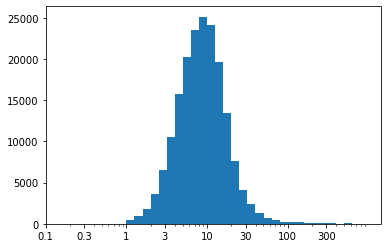

## (Visualization 2)

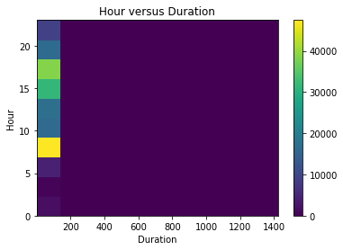

## (Visualization 3)

Greater number of bike users are young people with an average age 34-35. The young age groups are morelikely to spend more time during bike rides.

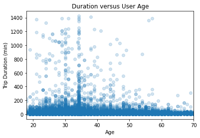

## (Visualization 4)

> Though from the data male gender has the highest values, they have short trip duration shown in the visualization below. The gender labelled as other has the longest trip duration though it has the smallest value in the data.

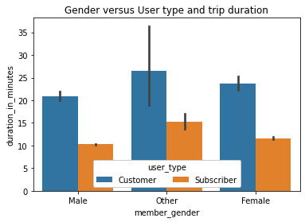

## (Visualization 5)

> Customer user type has the highest value in the data, this user type are not bike sharers, and they spend more time during bike rides.

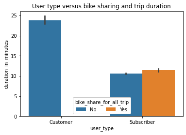